# BIKE TRIPS

Nguyen Duy

7/24/2021

This analysis is based on case study 1 in the **Google Analytics Certificate**. The purpose of this activity is to consolidate download datasets on divvy-tripdata follow this link, after that, I clean data and conduct some simple data analysis.

## Contents

##### I. Set up environment

##### II. Import data

##### III. Check the data

##### IV. Clean and prepare data

##### V. Conduct analysis

##### VI. Export data for further analysis

### GO!

##### I. Set up environment

Before using **read.csv()** we need to install some required packages. If you download those packages before, you should use this code chunk fisrt:

```r
chooseCRANmirror(graphics=FALSE, ind=1)
knitr::opts_chunk$set(echo = TRUE)
```

```r
library(tidyverse) # for data import and wrangling
library(lubridate) # for handling with datetype
```

```r
library(knitr)
library(ggplot2)   # ggplot for visualizations
library(skimr)     # deeply understanding dataset
library(janitor)   # for removing emty rows and cols
library(here)
library(scales)    # change scale in chart axis
library(dplyr)
#if you want to creat a map with R, you can run the code chunk below (remove #)

#install.packages("ggmap")    #map for visualizing with Chicago map
#library(ggmap)
#install.packages("maps")
#library(maps)
#install.packages("ggthemes") #to create a map of bike trips
#library(ggthemes)
#install.packages("scales")   # scales to set the labels from scientific value to numeric
#install.packages("geosphere")
#library(geosphere)
```

#### II. Import data

```r
#setwd("C:\\Users\\ADMIN\\Documents\\data1")
df007 <- read.csv("./data1/202007-divvy-tripdata.csv")
df008 <- read.csv("./data1/202008-divvy-tripdata.csv")
df009 <- read.csv("./data1/202009-divvy-tripdata.csv")
df010 <- read.csv("./data1/202010-divvy-tripdata.csv")
df011 <- read.csv("./data1/202011-divvy-tripdata.csv")
df012 <- read.csv("./data1/202012-divvy-tripdata.csv")
df101 <- read.csv("./data1/202101-divvy-tripdata.csv")
df102 <- read.csv("./data1/202102-divvy-tripdata.csv")
df103 <- read.csv("./data1/202103-divvy-tripdata.csv")
df104 <- read.csv("./data1/202104-divvy-tripdata.csv")
df105 <- read.csv("./data1/202105-divvy-tripdata.csv")
df106 <- read.csv("./data1/202106-divvy-tripdata.csv")
```

#### III. Check the data

We must make sure that the data of different files perfectly fit together before and we can combine it into a single large dataset

```r
colnames(df007)
```

```
##  [1] "ride_id"            "rideable_type"      "started_at"
##  [4] "ended_at"           "start_station_name" "start_station_id"
##  [7] "end_station_name"   "end_station_id"     "start_lat"
## [10] "start_lng"          "end_lat"            "end_lng"
## [13] "member_casual"
```

```r
#colnames(df008)
#colnames(df009)
#colnames(df010)
#colnames(df011)
#colnames(df012)
#colnames(df101)
#colnames(df102)
#colnames(df103)
#colnames(df104)
#colnames(df105)
#colnames(df106)
```

OK! perfect fit, all 12 datasets have the same cols, now let’s see how’s the real data inside them look like:

```r
str
```

```
## function (object, ...)
## UseMethod("str")
## <bytecode: 0x00000000146ddda8>
## <environment: namespace:utils>
```

```r
str(df007)
```

```
## 'data.frame':    551480 obs. of  13 variables:
##  $ ride_id           : chr  "762198876D69004D" "BEC9C9FBA0D4CF1B" "D2FD8EA432C77EC1" "54AE594E20B35881" ...
##  $ rideable_type     : chr  "docked_bike" "docked_bike" "docked_bike" "docked_bike" ...
##  $ started_at        : chr  "2020-07-09 15:22:02" "2020-07-24 23:56:30" "2020-07-08 19:49:07" "2020-07-17 19:06:42" ...
##  $ ended_at          : chr  "2020-07-09 15:25:52" "2020-07-25 00:20:17" "2020-07-08 19:56:22" "2020-07-17 19:27:38" ...
##  $ start_station_name: chr  "Ritchie Ct & Banks St" "Halsted St & Roscoe St" "Lake Shore Dr & Diversey Pkwy" "LaSalle St & Illinois St" ...
##  $ start_station_id  : int  180 299 329 181 268 635 113 211 176 31 ...
##  $ end_station_name  : chr  "Wells St & Evergreen Ave" "Broadway & Ridge Ave" "Clark St & Wellington Ave" "Clark St & Armitage Ave" ...
##  $ end_station_id    : int  291 461 156 94 301 289 140 31 191 142 ...
##  $ start_lat         : num  41.9 41.9 41.9 41.9 41.9 ...
##  $ start_lng         : num  -87.6 -87.6 -87.6 -87.6 -87.6 ...
##  $ end_lat           : num  41.9 42 41.9 41.9 41.9 ...
##  $ end_lng           : num  -87.6 -87.7 -87.6 -87.6 -87.6 ...
##  $ member_casual     : chr  "member" "member" "casual" "casual" ...
```

```r
#str(df008)
#str(df009)
#str(df010)
#str(df011)
#str(df012)
#str(df101)
#str(df102)
#str(df103)
#str(df104)
#str(df105)
#str(df106)
```

Oh! they are quite good and fit, so we can combine them into a single dataset right now! After that, we remove empty rows and cols

```r
bike_rides <- rbind(df007,df008,df009,df010,df011,df012,df101,df102,df103,df104,df105,df106)
dim(bike_rides) #check number of rows before remove empty
```

```
## [1] 4460151      13
```

```r
bike_rides <- janitor:: remove_empty(bike_rides, which = c("cols"))
bike_rides <- janitor:: remove_empty(bike_rides, which = c("rows"))
dim(bike_rides) #check number of rows after remove empty
```

```
## [1] 4460151      13
```

Look at the new dataset one more time!

```r
# take a glance at the data
glimpse(bike_rides)
```

```
## Rows: 4,460,151
## Columns: 13
## $ ride_id            <chr> "762198876D69004D", "BEC9C9FBA0D4CF1B", "D2FD8EA432~
## $ rideable_type      <chr> "docked_bike", "docked_bike", "docked_bike", "docke~
## $ started_at         <chr> "2020-07-09 15:22:02", "2020-07-24 23:56:30", "2020~
## $ ended_at           <chr> "2020-07-09 15:25:52", "2020-07-25 00:20:17", "2020~
## $ start_station_name <chr> "Ritchie Ct & Banks St", "Halsted St & Roscoe St", ~
## $ start_station_id   <chr> "180", "299", "329", "181", "268", "635", "113", "2~
## $ end_station_name   <chr> "Wells St & Evergreen Ave", "Broadway & Ridge Ave",~
## $ end_station_id     <chr> "291", "461", "156", "94", "301", "289", "140", "31~
## $ start_lat          <dbl> 41.90687, 41.94367, 41.93259, 41.89076, 41.91172, 4~
## $ start_lng          <dbl> -87.62622, -87.64895, -87.63643, -87.63170, -87.626~
## $ end_lat            <dbl> 41.90672, 41.98404, 41.93650, 41.91831, 41.90799, 4~
## $ end_lng            <dbl> -87.63483, -87.66027, -87.64754, -87.63628, -87.631~
## $ member_casual      <chr> "member", "member", "casual", "casual", "member", "~
```

```r
skim_without_charts(bike_rides)
```

Data summary

| Name | bike_rides |
| --- | --- |
| Number of rows | 4460151 |
| Number of columns | 13 |
| _______________________ |  |
| Column type frequency: |  |
| character | 9 |
| numeric | 4 |
| ________________________ |  |
| Group variables | None |

**Variable type: character**

| skim_variable | n_missing | complete_rate | min | max | empty | n_unique | whitespace |
| --- | --- | --- | --- | --- | --- | --- | --- |
| ride_id | 0 | 1.00 | 16 | 16 | 0 | 4459942 | 0 |
| rideable_type | 0 | 1.00 | 11 | 13 | 0 | 3 | 0 |
| started_at | 0 | 1.00 | 19 | 19 | 0 | 3813396 | 0 |
| ended_at | 0 | 1.00 | 19 | 19 | 0 | 3801221 | 0 |
| start_station_name | 0 | 1.00 | 0 | 53 | 282068 | 713 | 0 |
| start_station_id | 83583 | 0.98 | 0 | 35 | 199111 | 1275 | 0 |
| end_station_name | 0 | 1.00 | 0 | 53 | 315109 | 714 | 0 |
| end_station_id | 97216 | 0.98 | 0 | 35 | 218354 | 1275 | 0 |
| member_casual | 0 | 1.00 | 6 | 6 | 0 | 2 | 0 |

**Variable type: numeric**

| skim_variable | n_missing | complete_rate | mean | sd | p0 | p25 | p50 | p75 | p100 |
| --- | --- | --- | --- | --- | --- | --- | --- | --- | --- |
| start_lat | 0 | 1 | 41.90 | 0.04 | 41.64 | 41.88 | 41.90 | 41.93 | 42.08 |
| start_lng | 0 | 1 | -87.64 | 0.03 | -87.87 | -87.66 | -87.64 | -87.63 | -87.52 |
| end_lat | 5286 | 1 | 41.90 | 0.04 | 41.51 | 41.88 | 41.90 | 41.93 | 42.16 |
| end_lng | 5286 | 1 | -87.64 | 0.03 | -88.07 | -87.66 | -87.64 | -87.63 | -87.44 |

```r
#str(bike_rides)
#head(bike_rides)
#colnames(bike_rides)
```

After taking a look at the data, you can see that some of the columns were formatted in the wrong way, so we must change the format of data before taking analysis, for example: **started_at, ended_at (chr)** we need to format the data to the right datatype.

```r
bike_rides$started_at <- lubridate:: ymd_hms(bike_rides$started_at)
bike_rides$ended_at <- lubridate:: ymd_hms(bike_rides$ended_at)
```

At this point, the data was formatted in the right datatype, but the name of columns were named not intuitive, you can consider renaming cols by using **rename(table, new_col_name=old_col_name,…)**, but I will change the name after this analysis by using **MS Power BI**

#### IV. Clean and prepare data

In the 2019 dataset, we need to change the variables of the member_casual column but fortunately we don’t need to do that in the 2020 dataset and later, but we can we can do that by using this code chunk:

```r
#bike_rides <-  bike_rides %>%
           #  mutate(member_casual = recode(member_casual,"Subscriber" = "member",
            #                               ,"Customer" = "casual"))
```

We can detect the hour value in the **started_at** col to determine what is the mode time people rent for a bike.

```r
bike_rides$started_hour <- lubridate:: hour(bike_rides$started_at)
bike_rides$ended_hour <- lubridate:: hour(bike_rides$ended_at)
bike_rides$total_time_rent <- difftime(bike_rides$ended_at,bike_rides$started_at, units = "mins")
# Convert "total_time_rent" from Factor to numeric so we can run calculations on the data
is.factor(bike_rides$total_time_rent)
```

```
## [1] FALSE
```

```r
class(bike_rides$total_time_rent)
```

```
## [1] "difftime"
```

```r
bike_rides$total_time_rent <- as.numeric(as.character(bike_rides$total_time_rent))
is.numeric(bike_rides$total_time_rent)
```

```
## [1] TRUE
```

```r
bike_rides_v2 <- bike_rides[!(bike_rides$start_station_name == "HQ QR" | bike_rides$total_time_rent<0),]
```

If you want to calculate the distance between two locations base on latitude and longitude, please run the code below (remove #)

```r
#bike_rides$ride_length <- bike_rides %>%
       #distHaversine(cbind(start_lng, start_lat),
                                #cbind(lag(end_lng), lag(end_lat)))
```

The data seem to be ready for analysis! let’s go!

#### V. Conduct analysis

I really want to show you the map of Chicago and where the bike trips were, but my device not strong enough to run all the code, so if your device has RAM >=8G, I highly recommend you run the code chunk below:

```r
#chicago_map <- get_stamenmap(bbox = c(left = -88.5,bottom= 41.5,right= -87,
#               top = 42 ), zoom = 10, maptype = "terrain")
#ggmap(chicago_map)+
#  geom_point(data = bike_rides, aes(x= start_lng, y = start_lat), size = .3)+
# theme_map()
#ggsave("chicago_map.png)
```

Now, I will create a visualization to demonstrate the mode hour of day people take a bike trip.

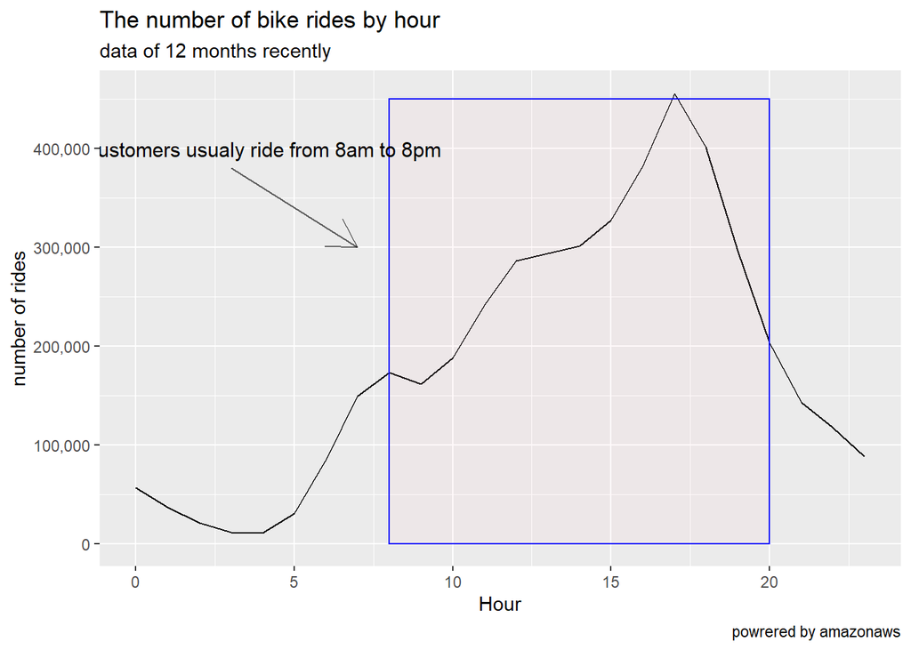

```r
# What is the time customers usually rent for bikes (start_hour)?

bike_rides %>% count(started_hour, sort = T) %>%
  ggplot() +
  geom_line(aes(x= started_hour, y = n))+
  scale_y_continuous(labels = comma)+
  labs(title = "The number of bike rides by hour", y= "number of rides", x = "Hour",
    subtitle = "data of 12 months recently", caption = "powrered by amazonaws")+
  annotate("rect", xmin = 8, xmax = 20, ymin = 0, ymax = 450000,
           alpha = 0.1, color = "blue", fill = "pink")+
  annotate("segment", x = 3, xend = 7, y = 380000, yend = 300000, color = "black", alpha = 0.6, arrow = arrow())+
  annotate("text", x = 4, y = 400000, label = "Customers usualy ride from 8am to 8pm", size = 4, color = "black")
```

```r
# Customers usually rent bikes in the time frame from 8 am to 8 pm
#ggsave("rides_by_hour.png)
```

Compare members and casual users:

```r
#aggregate(bike_rides_v2$total_time_rent ~ bike_rides_v2$member_casual, FUN = mean)
#aggregate(bike_rides_v2$total_time_rent ~ bike_rides_v2$member_casual, FUN = median)
aggregate(bike_rides_v2$total_time_rent ~ bike_rides_v2$member_casual, FUN = max)
```

```
##   bike_rides_v2$member_casual bike_rides_v2$total_time_rent
## 1                      casual                      55944.15
## 2                      member                      33421.37
```

```r
aggregate(bike_rides_v2$total_time_rent ~ bike_rides_v2$member_casual, FUN = min)
```

```
##   bike_rides_v2$member_casual bike_rides_v2$total_time_rent
## 1                      casual                             0
## 2                      member                             0
```

Ok, that’s it for today, I will conduct more analysis and vizs in Power BI dashboard and SQL, hope to have you back.

#### VI. Export data to further analysis

Now, it’s time to export our data into a csv file in a specified folder, remember to save the vizs and map too!

```r
#write.csv(bike_rides, "C:\\Users\\ADMIN\\Documents\\data1\\bike_rides_v2.csv")
```

## Thank you for reading